# Spatial Segregation: Chicago Crime continued

# Task 1: Prepare data for segregation

We can get a more principled measure of the violent crime ratio using a spatial segregation model. The `seg` package implements the theory of spatial segregation (Reardon and O’Sullivan 2004).

Before we segregate, though, let’s reduce the dataset to a smaller section.

## Instructions I

- Install `seg` package from CRAN, load `spatstat` and `sf` library.
- Ensure that `city` boundary and the `crime_violent` simple feature object is read in (check last tutorial).
- Create a circle around the list of supplied coordinates, and make it a simple feature object.
  - You have several options here. Perhaps elaborate on a whiteboard first?
- Use the circle to crop `crime_violent` simple feature object

```r
# Libraries
library(spatstat)

# Data
crime_violent <- ________("data/crime-violent-sf.rds")
Hilton <- __________

# Create a circle with 5000m radius around Hilton
c <- ____________________

# Plot the result to check it fits within Chicago
______
```

### Solution - Make a circle

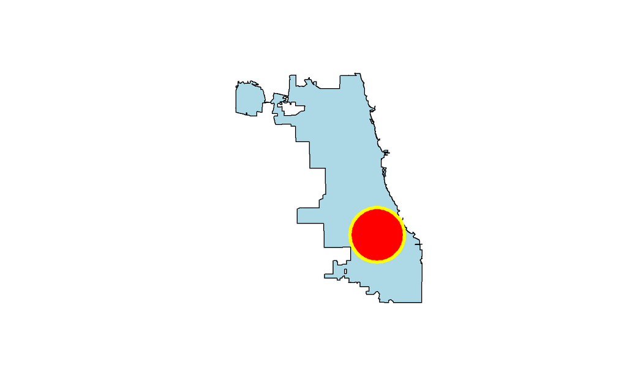

## Instructions II - Crop the crime points by new circle

- bring in the old sf object `crime_violent` / `crime_v`
- crop it to the extent of the 5km buffer using the circle you created above
- convert the cropped `crime_centre` result to `ppp` object
  - consider using the `disc()` function to create a window, or convert circle c to an `owin` object
  - use `crimetype` column as a basis for marks, after converting it to factor
- plot the split `crime_violent` ppp object

```r
# Use the circle to clip crimes
crime_centre <- crime_violent %>%
  _____________(c)


# Convert the cropped crimes to ppp object, consider how you can create a window

crime_violent <- ______(st_coordinates(crime_centre), W = ____)
marks(crime_violent) = as.factor(crime_centre$crimetype)
plot(split(crime_violent))
```

### Solution

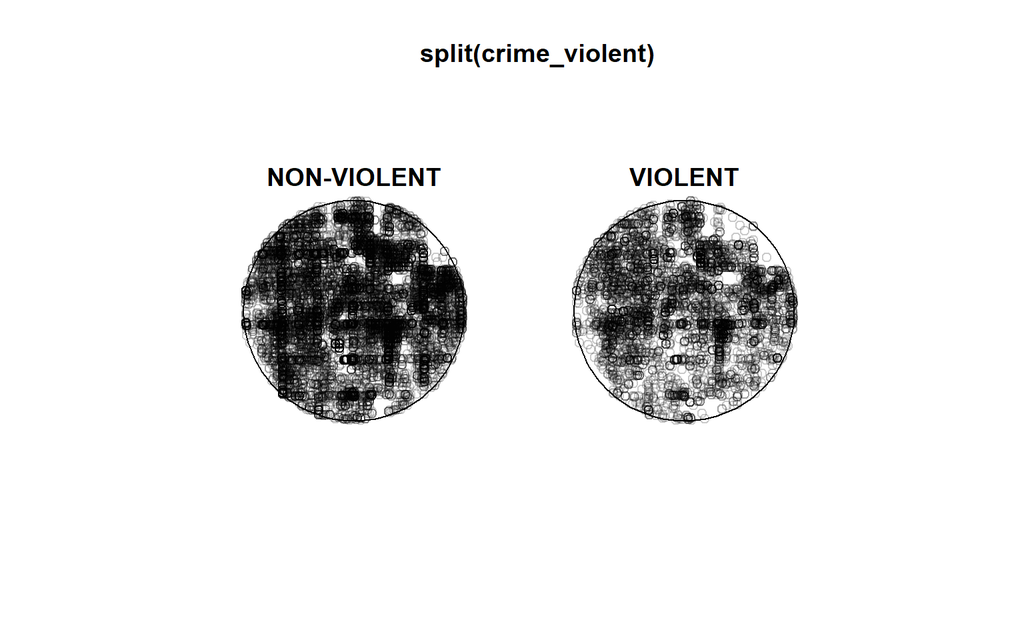

# Task 2: Segregation probabilities

Compute the probabilities for violent and non-violent crimes as a smooth surface, as well as the p-values for a point-wise test of segregation. This is done by calling `spseg()` with `smoothing = kernel` .

The `spseg()` function takes data and marks as two separate arguments, and you need to process the marks into a numeric matrix of at least two columns. We shall use `case_when()` again to mutate/create the violent and non-violent columns out of the `crimetype`

## Instructions

- Install the `seg` package
- Ensure the `crime_centre` points data is loaded.
- Create a column `violent` by assigning crimetype values of “violent” the number 1 and “non-violent” the number 0. Since we need two columns, create a nonviolent column doing the reverse.
  - select the two new columns, drop the geometry and assign the result to `cc` object
- Run `spseg()` function by
- assigning the coordinates of `crime_centre` to x,
- assigning `cc` numeric matrix to data argument and selecting `kernel` as a smoothing argument
- Use `spplot()` to plot the map for the violent/non-violent crime probability in your conference area.

```r
#install.packages("seg")
library(seg)

# data needs to be in a numeric matrix
cc <- crime_centre %>%
  mutate(violent = case_when(
    _________________,
   _________________
    ),nonviolent = case_when(
    _________________,
    _________________
  )) %>%
  select(violent, nonviolent) %>% st_drop_geometry()

# run the spseg() function
pp <- spseg(x = ______(crime_centre), data=______,
            smoothing = ______, maxdist = 3000)

# Explore result
print(pp, digits = 3)
spplot(pp, main = "Kernel")

# Detach library if you wish to try others
detach("package:seg")
```

### Solution

```
##
##  Reardon and O'Sullivan's spatial segregation measures
##
## Dissimilarity (D)     : 0.175
## Relative diversity (R): 0.042
## Information theory (H): 0.037
## Exposure/Isolation (P):
##            violent nonviolent
## violent      0.328      0.672
## nonviolent   0.286      0.714
## --
## The exposure/isolation matrix should be read horizontally.
## Read 'help(spseg)' for more details.
```

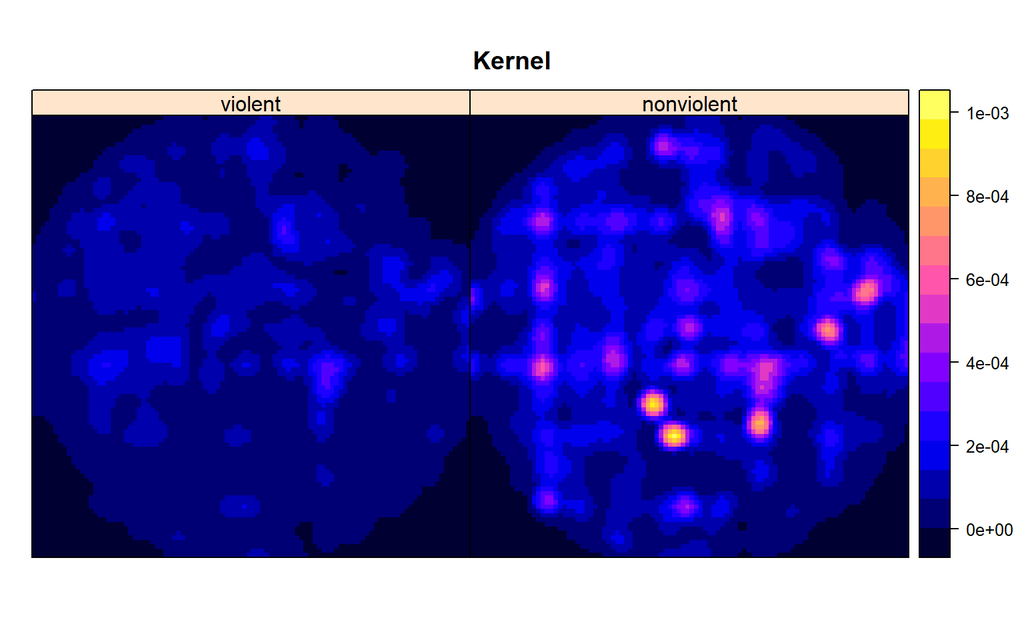

Good work! The simulation shows that non-violent crime dominates around my conference location.

# Task 3: Spatialkernel - Bandwidth selection

We can get a more principled measure of the violent crime ratio using a spatial segregation model. The `spatialkernel` package implements the theory of spatial segregation (Reardon and O’Sullivan 2004).

The first step is to compute the optimal bandwidth for kernel smoothing under the segregation model. A small bandwidth would result in a density that is mostly zero, with spikes at the event locations. A large bandwidth would flatten out any structure in the events, resulting in a large “blob” across the whole window. Somewhere between these extremes is a bandwidth that best represents an underlying density for the process.

`spseg()` from the `spatialkernel` will scan over a range of bandwidths and compute a test statistic using a cross-validation method. The bandwidth that maximizes this test statistic is the one to use. The returned value from `spseg()` in this case is a list, with `h` and `cv` elements giving the values of the statistic over the input `h` values. The `spatialkernel` package supplies a `plotcv` function to show how the test value varies. The `hcv` element has the value of the best bandwidth. For more information, see [link](https://rdrr.io/cran/spatialkernel/man/spatialkernel-package.html)

## Instructions

- Install `spatialkernel` package from Github.
- Ensure that `spatstat` is loaded and the `crime_centre` object is read in (see above).
- Create a `pts` object by extracting coordinates from `crime_centre` and putting them into a matrix
- Create `marks` vector by extracting crimetype from `crime_centre`.
- Set `h`, the bandwidth values to try, then call `spatialkernel::spseg(`).
- You need to provide the start value, 100, then end value, 1000, and the step size, between 50 and 100. This can be very compute-intensive.
- Assign the result to `bw_choice`.
- Plot the test statistic vs. the bandwidth.
- Call `plotcv()` on `bw_choice`.
- Highlight the best bandwidth by adding a vertical line where the test statistic is maximized.

```r
# Install spatialkernel (the CRAN version is outdated, so you need to grab the most recent maintained version from Github). You may need to install.packages("devtools") and then run:
#devtools::install_github("becarioprecario/spatialkernel")

# Libraries
library(spatstat)
library(spatialkernel)

# Data
pts <- as.matrix(st_coordinates(crime_centre))
marks <- crime_centre[["crimetype"]]

# Scan from 100m to 1000m in steps of 100m
?spseg()
bw_choice <- ____________(pts, marks,
    h = seq(___, ___, by = ___),
    opt = 1)

# Plot the results and highlight the best bandwidth
plotcv(bw_choice); abline(v = bw_choice$___, lty = 2, col = "red")

# Print the best bandwidth
print(bw_choice$___)
```

### Solution

```
##
## Calculating cross-validated likelihood function
```

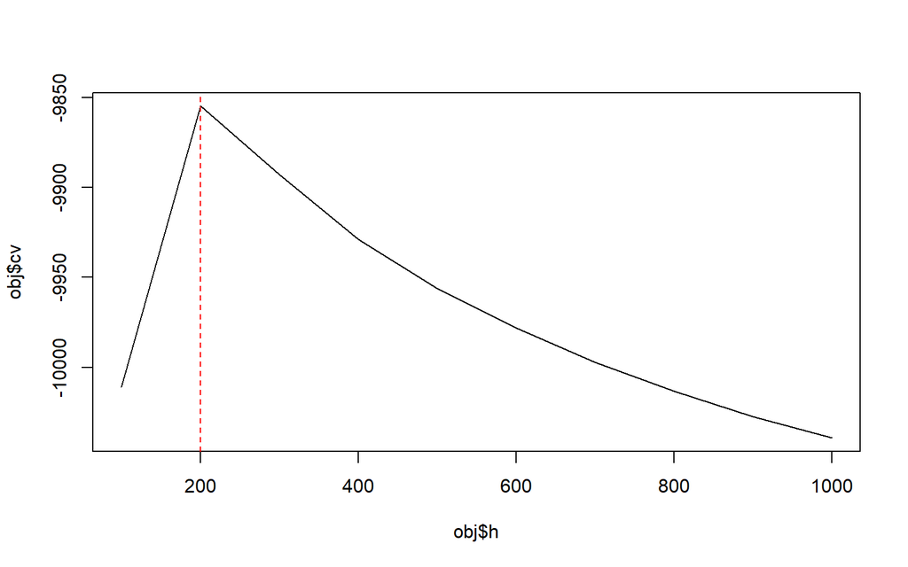

```
## [1] 200
```

Amazing! Now you know the optimal smoothing parameter, you can do some kernel smoothing simulations.

# Task 4: Spatialkernel - Segregation probabilities

The second step is to compute the probabilities for violent and non-violent crimes as a smooth surface, as well as the p-values for a point-wise test of segregation. This is done by calling `spseg()` with `opt = 3` and a fixed bandwidth parameter `h`.

## Instructions

- Ensure the `pts` and `marks` data are loaded.
- You can also get the optimum bandwidth from the `hcv` element of `bw_choice`.
- Set the bandwidth parameter h.
- Run the function for 10 simulations only via the `ntest` parameter.
- Specify a bounding polygon `poly` as a matrix of coordinates of the circle `c` you created in Task 1
- The output consists of probability maps for each class in the marks of the data. Plot the map for the violent crimes. Add “Violent crime” as the title to your plots.

```r
# Set the correct bandwidth and run for 10 simulations only
seg10 <- spseg(
    pts = pts,
    marks = marks,
    h = ___,
    opt = 3,
    ntest = ___,
    proc = FALSE,
    poly = as.matrix(_________))

# Plot the segregation map for violent crime
plotmc(seg10, "___")
```

## Solution

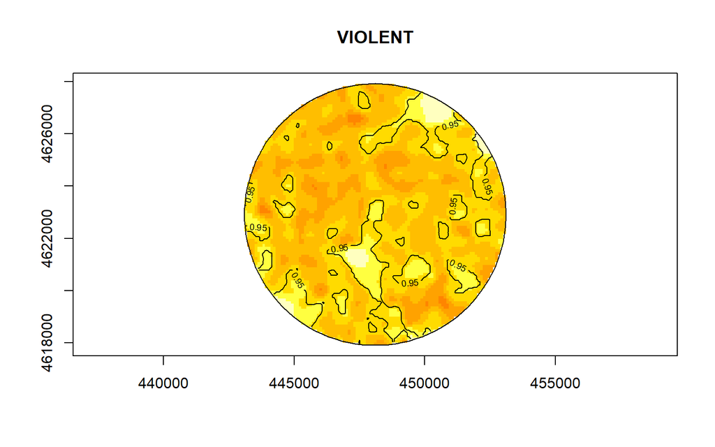

Good work! The simulation shows that crime is relatively more violent in the town centre and South Western edge.

# Task 5: Spatialkernel - Mapping segregation

With a base map and some image and contour functions we can display both the probabilities and the significance tests over the area with more control than the `plotmc()` function.

The `seg` object is a list with several components. The X and Y coordinates of the grid are stored in the `$gridx` and `$gridy` elements. The probabilities of each class of data (violent or non-violent crime) are in a matrix element `$p` with a column for each class. The p-value of the significance test is in a similar matrix element called `$stpvalue`. Rearranging columns of these matrices into a grid of values can be done with R’s matrix() function. From there you can construct list objects with a vector `$x` of X-coordinates, `$y` of Y-coordinates, and `$z` as the matrix. You can then feed this to `image()` or `contour()` for visualization.

This process may seem complex, but remember that with R you can always write functions to perform complex tasks and those you may repeat often. For example, to help with the mapping in this exercise you will create a function that builds a map from four different items.

## Instructions

- Inspect the segregation object.
  - Use `str()` to see the structure of `seg`.
  - Set `ncol` as the length of one of the elements of `seg`.
- Create prob_violent as a list with
  - x as the gridx element of `seg`.
  - y as the gridy element.
  - z as a matrix with the “violent crime” column of the p element.
- Create `p_value` as in the previous step, except that the `z` element is logical, and `TRUE` when the `stpvalue` element of seg is less than 0.05.
- Call the `segmap()` function shown in the script to find areas where the probability of a crime being violent is above 0.15. Use 0.05 as the lower probability.

```r
# Inspect the structure of the spatial segregation object
str(___)

# Get the number of columns in the data so we can rearrange to a grid
ncol <- length(seg$___)

# Rearrange the probability column into a grid
prob_violent <- list(x = seg$___,
                     y = seg$___,
                     z = matrix(seg$___[, "Violent crime"],
                                ncol = ncol))
# You have basically georeferenced the image within data's coordinates
image(prob_violent)

# Rearrange the p-values, but choose a p-value threshold
p_value <- list(x = seg$___,
                y = seg$___,
                z = matrix(seg$___[, "Violent crime"]< 0.05,
                                ncol = ncol))
image(p_value)


# Create a mapping function
segmap <- function(prob_list, pv_list, low, high){

  # background map
  #library(raster)

  # p-value areas
  image(pv_list,
        col = c("#00000000", "#FF808080"), add = TRUE)

  # probability contours
  contour(prob_list,
          levels = c(low, high),
          col = c("#206020", "red"),
          labels = c("Low", "High"),
          add = TRUE)

  # boundary window
  plot(Window(mpp), add = TRUE)
}

# Map the probability and p-value
segmap(prob_violent, p_value, ___, ___)
```

### Solution

```
## List of 11
##  $ pvalue  : num 0.1
##  $ stpvalue: num [1:10201, 1:2] NA NA NA NA NA NA NA NA NA NA ...
##   ..- attr(*, "dimnames")=List of 2
##   .. ..$ : NULL
##   .. ..$ : chr [1:2] "VIOLENT" "NON-VIOLENT"
##  $ ntest   : num 10
##  $ gridx   : num [1:101] 443154 443253 443351 443450 443549 ...
##  $ gridy   : num [1:101] 4617965 4618064 4618163 4618262 4618361 ...
##  $ p       : num [1:10201, 1:2] NA NA NA NA NA NA NA NA NA NA ...
##   ..- attr(*, "dimnames")=List of 2
##   .. ..$ : NULL
##   .. ..$ : chr [1:2] "NON-VIOLENT" "VIOLENT"
##  $ pts     : num [1:16600, 1:2] 450781 448513 448057 449915 445558 ...
##   ..- attr(*, "dimnames")=List of 2
##   .. ..$ : chr [1:16600] "1" "2" "3" "4" ...
##   .. ..$ : chr [1:2] "X" "Y"
##  $ marks   : chr [1:16600] "VIOLENT" "NON-VIOLENT" "VIOLENT" "VIOLENT" ...
##  $ h       : num 200
##  $ opt     : num 3
##  $ poly    : num [1:121, 1:2] 453104 453097 453077 453043 452995 ...
##   ..- attr(*, "dimnames")=List of 2
##   .. ..$ : NULL
##   .. ..$ : chr [1:2] "X" "Y"
```

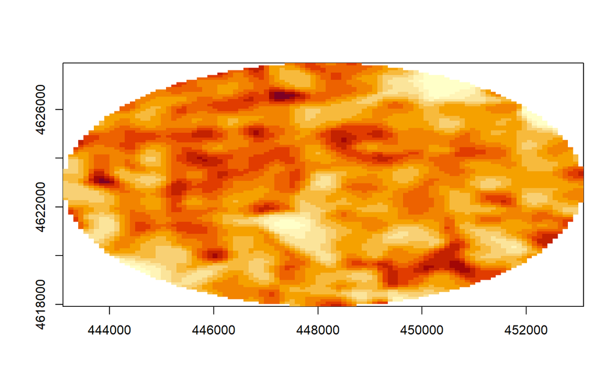

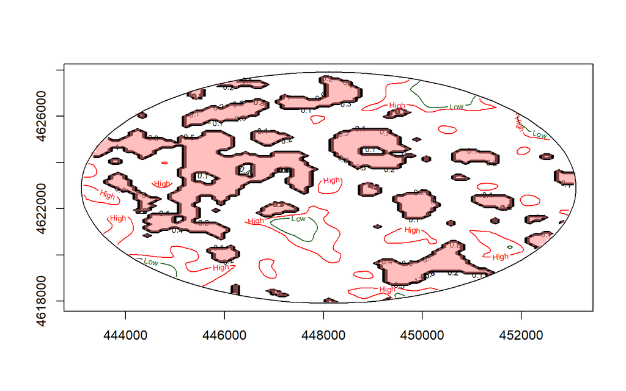

[output not shown]